# notebook_eda

### IMPORTS

```python
import pandas as pd
import seaborn as sns
import matplotlib.pyplot as plt
```

### Carga de datos

```python
df = pd.read_csv("..\Data\Raw\Dataset_viviendas_final.csv")
print(df.columns)
columns = ['comuna', 'titulo', 'precio_uf', 'm2_totales', 'm2_construidos',
       'banos', 'dormitorios', 'antiguedad_anos', 'estacionamientos', 'jardin',
       'piscina', 'quincho', 'condominio_cerrado', 'educacion', 'comercios',
       'salud', 'tipo_vivienda', 'direccion']
print(len(columns))
df_a_visualizar = df[columns]
display(df_a_visualizar)
```

```
Index(['comuna', 'titulo', 'precio_uf', 'm2_totales', 'm2_construidos',
       'banos', 'dormitorios', 'antiguedad_anos', 'estacionamientos', 'jardin',
       'piscina', 'quincho', 'condominio_cerrado', 'educacion', 'comercios',
       'salud', 'url', 'tipo_vivienda', 'direccion'],
      dtype='object')
18
```

|  | comuna | titulo | precio_uf | m2_totales | m2_construidos | banos | dormitorios | antiguedad_anos | estacionamientos | jardin | piscina | quincho | condominio_cerrado | educacion | comercios | salud | tipo_vivienda | direccion |
| --- | --- | --- | --- | --- | --- | --- | --- | --- | --- | --- | --- | --- | --- | --- | --- | --- | --- | --- |
| 0 | Cerrillos | Casa Remodelada Con Dos Departamentos Independ... | 3950.0 | 190.0 | 120.0 | 1 | 3 | 59 | 1 | True | True | True | True | True | True | True | casa | P.º De Las Guaguas 8192, 9201177 Cerrillos, Re... |
| 1 | Cerrillos | Casa 2 Pisos 5d 2b 2estacionamientos Potencial... | 5000.0 | 237.0 | 139.0 | 2 | 5 | 62 | 2 | True | True | True | True | True | True | True | casa | Avenida Los Cerrillos, 570, Parque Bicentenari... |
| 2 | Cerrillos | Espaciosa Casa De Dos Pisos En Cerrillos-lista... | 6368.0 | 250.0 | 189.0 | 2 | 4 | 0 | 2 | True | True | True | True | False | False | False | casa | Los Claveles 447, Cerrillos, El Mirador, Cerri... |
| 3 | Cerrillos | Remodelada Cerrillos Portal Oeste | 3590.0 | 200.0 | 76.0 | 2 | 3 | 17 | 1 | True | True | False | True | True | True | False | casa | Los Nisperos 7551, Plaza Oeste, Cerrillos, RM ... |
| 4 | Cerrillos | Venta Casa 4hab 3ba Comuna Cerrillos | 4990.0 | 143.0 | 107.0 | 3 | 4 | 17 | 2 | True | True | True | True | True | True | False | casa | Avenida Aeropuerto, 7000, Plaza Oeste, Cerrill... |
| ... | ... | ... | ... | ... | ... | ... | ... | ... | ... | ... | ... | ... | ... | ... | ... | ... | ... | ... |
| 6227 | Ñuñoa | Venta Depto 1 O 2d/2b/est/bod- Metro Monseñor ... | 6300.0 | 85.0 | 77.0 | 2 | 1 | 3 | 1 | True | True | False | True | True | True | True | departamento | Monseñor Eyzaguirre Con Con Crescente Errazuri... |
| 6228 | Ñuñoa | Departamento Zañartu Id: 144394 | 4100.0 | 59.0 | 57.0 | 2 | 2 | 3 | 1 | True | True | True | False | True | True | True | departamento | Zañartu, Estadio Nacional, Ñuñoa, RM (Metropol... |
| 6229 | Ñuñoa | Venta Departamento Semi Nuevo A Pasos Del Metr... | 6800.0 | 76.0 | 76.0 | 2 | 2 | 2 | 1 | True | True | False | True | True | True | True | departamento | Alcalde Eduardo Castillo Velasco 2958, Ñuñoa, ... |
| 6230 | Ñuñoa | Lindo Depto, Disponibilidad Inmediata | 5100.0 | 82.0 | 77.0 | 2 | 3 | 0 | 0 | True | True | False | True | True | True | True | departamento | Lindo Depto, Disponibilidad Inmediata, Estadio... |
| 6231 | Ñuñoa | Departamento En Venta De 2 Dorm. En Ñuñoa | 2600.0 | 50.0 | 45.0 | 1 | 2 | 0 | 0 | True | True | True | True | True | False | False | departamento | Metro Rodrigo De Araya - Zañartu, Estadio Naci... |

6232 rows × 18 columns

```python
for columna in ['precio_uf', 'm2_totales', 'm2_construidos',
       'banos', 'dormitorios', 'antiguedad_anos', 'estacionamientos']:
    print(df_a_visualizar[columna].mean(), "promedio", columna)
    print(df_a_visualizar[columna].max(), "maximo", columna)
    print(df_a_visualizar[columna].min(), "minimo", columna)
    print(df_a_visualizar[columna].median(), "mediana", columna)
```

```
10770.988767650835 promedio precio_uf
230000.0 maximo precio_uf
382.0 minimo precio_uf
6400.0 mediana precio_uf
472.4472737483954 promedio m2_totales
110000.0 maximo m2_totales
0.0 minimo m2_totales
146.0 mediana m2_totales
160.3819672657253 promedio m2_construidos
11168.0 maximo m2_construidos
0.0 minimo m2_construidos
107.0 mediana m2_construidos
2.5284017971758663 promedio banos
15 maximo banos
0 minimo banos
2.0 mediana banos
3.243581514762516 promedio dormitorios
17 maximo dormitorios
0 minimo dormitorios
3.0 mediana dormitorios
34.091302952503206 promedio antiguedad_anos
20150 maximo antiguedad_anos
0 minimo antiguedad_anos
10.0 mediana antiguedad_anos
1.967426187419769 promedio estacionamientos
150 maximo estacionamientos
0 minimo estacionamientos
1.0 mediana estacionamientos
```

[figure not shown]

```python
import pandas as pd
import seaborn as sns
import matplotlib.pyplot as plt
import numpy as np

df_a_visualizar = pd.read_csv("..\Data\Raw\Dataset_viviendas_final.csv")

limite_precio = df_a_visualizar['precio_uf']
limite_m2 = df_a_visualizar['m2_construidos']
df_filtrado = df_a_visualizar[
    (df_a_visualizar['precio_uf'] <= limite_precio) &
    (df_a_visualizar['m2_construidos'] <= limite_m2)
]

sns.set_style("ticks")
sns.set_context("talk")
plt.figure(figsize=(15, 8))
sns.scatterplot(data=df_filtrado, x='precio_uf', y='m2_construidos', alpha=0.5)

precio_min = df_filtrado['precio_uf'].min()
precio_max = df_filtrado['precio_uf'].max()

nuevos_ticks = np.arange(start=precio_min, stop=precio_max, step=1000)

plt.xticks(ticks=nuevos_ticks, rotation=45)

plt.title('Relación Precio vs m² (con ticks personalizados)')
plt.xlabel('Precio en UF')
plt.ylabel('Metros Cuadrados Construidos')

plt.tight_layout()
plt.show()
```

[figure not shown]

```python
import pandas as pd
import seaborn as sns
import matplotlib.pyplot as plt
import numpy as np

df_a_visualizar = pd.read_csv("..\Data\Raw\Dataset_viviendas_final.csv")

limite_precio = df_a_visualizar['precio_uf']
limite_m2 = df_a_visualizar['antiguedad_anos']
df_filtrado = df_a_visualizar[
    (df_a_visualizar['precio_uf'] <= limite_precio) &
    (df_a_visualizar['antiguedad_anos'] <= limite_m2)
]

sns.set_style("ticks")
sns.set_context("talk")
plt.figure(figsize=(15, 8))
sns.scatterplot(data=df_filtrado, x='precio_uf', y='antiguedad_anos', alpha=0.5)

precio_min = df_filtrado['precio_uf'].min()
precio_max = df_filtrado['precio_uf'].max()

nuevos_ticks = np.arange(start=precio_min, stop=precio_max, step=1000)

plt.xticks(ticks=nuevos_ticks, rotation=45)

plt.title('Relación Precio vs m² (con ticks personalizados)')
plt.xlabel('Precio en UF')
plt.ylabel("antiguedad")

plt.tight_layout()
plt.show()
```

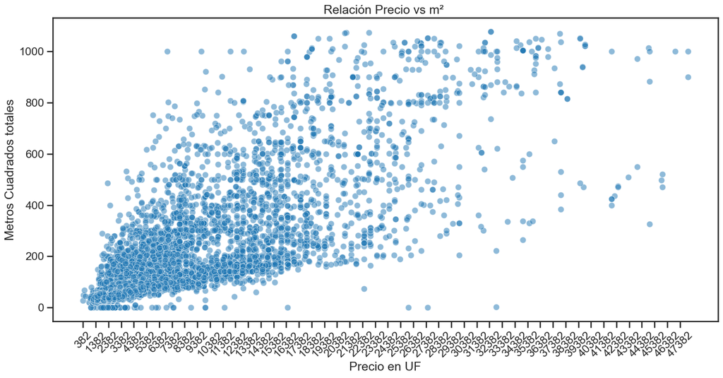

```python
import pandas as pd
import seaborn as sns
import matplotlib.pyplot as plt
import numpy as np

df_a_visualizar = pd.read_csv("..\Data\Raw\Dataset_viviendas_final.csv")

limite_precio = df_a_visualizar['precio_uf'].quantile(0.98)
limite_m2 = df_a_visualizar['m2_totales'].quantile(0.93)
df_filtrado = df_a_visualizar[
    (df_a_visualizar['precio_uf'] < limite_precio) &
    (df_a_visualizar['m2_totales'] < limite_m2)
]

sns.set_style("ticks")
sns.set_context("talk")
plt.figure(figsize=(15, 8))
sns.scatterplot(data=df_filtrado, x='precio_uf', y='m2_totales', alpha=0.5)

precio_min = df_filtrado['precio_uf'].min()
precio_max = df_filtrado['precio_uf'].max()

nuevos_ticks = np.arange(start=precio_min, stop=precio_max, step=1000)

plt.xticks(ticks=nuevos_ticks, rotation=45)

plt.title('Relación Precio vs m² ')
plt.xlabel('Precio en UF')
plt.ylabel('Metros Cuadrados totales')

plt.tight_layout()
plt.show()
```

[figure not shown]

```python
import pandas as pd
import seaborn as sns
import matplotlib.pyplot as plt
import numpy as np

df_a_visualizar = pd.read_csv("..\Data\Raw\Dataset_viviendas_final.csv")

limite_precio = df_a_visualizar['precio_uf'].quantile(0.98)
limite_m2 = df_a_visualizar['antiguedad_anos'].quantile(0.98)
df_filtrado = df_a_visualizar[
    (df_a_visualizar['precio_uf'] < limite_precio) &
    (df_a_visualizar['antiguedad_anos'] < limite_m2)
]

sns.set_style("ticks")
sns.set_context("talk")
plt.figure(figsize=(15, 8))
sns.scatterplot(data=df_filtrado, x='precio_uf', y='antiguedad_anos', alpha=0.5)

precio_min = df_filtrado['precio_uf'].min()
precio_max = df_filtrado['precio_uf'].max()

nuevos_ticks = np.arange(start=precio_min, stop=precio_max, step=1000)

plt.xticks(ticks=nuevos_ticks, rotation=45)

plt.title('Relación Precio vs m² (con ticks personalizados)')
plt.xlabel('Precio en UF')
plt.ylabel("antiguedad")

plt.tight_layout()
plt.savefig(
    "../Figures/relacion_precio_vs_antiguedad.png",
    dpi=300,
    bbox_inches="tight"
)
plt.show()
```

```python
import pandas as pd


try:
    df_a_visualizar = pd.read_csv("..\Data\Raw\Dataset_viviendas_final.csv")
    print("Dimensiones del DataFrame original:", df_a_visualizar.shape)

    # Calcular los límites para las columnas numéricas
    limite_precio = df_a_visualizar['precio_uf'].quantile(0.98)
    limite_m2 = df_a_visualizar['m2_totales'].quantile(0.93)
    limite_m2_construidos = df_a_visualizar['m2_construidos'].quantile(0.98)
    limite_antiguedad = df_a_visualizar['antiguedad_anos'].quantile(0.98)
    limite_estacionamientos = df_a_visualizar['estacionamientos'].quantile(0.98)
    limite_banos = df_a_visualizar['banos'].quantile(0.98)

    df_a_visualizar["comuna"] = (
        df_a_visualizar["comuna"]
        .astype(str)
        .str.strip()
        .str.replace(r"\s+", " ", regex=True)
        .str.replace(u"\xa0", " ")
        .str.title()
    )

    # Aplicar todos los filtros juntos
    df_filtrado = df_a_visualizar[
        (df_a_visualizar['precio_uf'] > 0) &
        (df_a_visualizar['precio_uf'] < limite_precio) &
        (df_a_visualizar['m2_totales'] > 0) &
        (df_a_visualizar['m2_totales'] < limite_m2) &
        (df_a_visualizar['m2_construidos'] > 0) &
        (df_a_visualizar['m2_construidos'] < limite_m2_construidos)&
        (df_a_visualizar['antiguedad_anos'] < limite_antiguedad) &
        (df_a_visualizar['estacionamientos'] < limite_estacionamientos) &
        (df_a_visualizar['banos'] < limite_banos) &



        (df_a_visualizar["comuna"].notna()) &
        (df_a_visualizar["comercios"].notna()) &
        (df_a_visualizar["condominio_cerrado"].notna()) &
        (df_a_visualizar["jardin"].notna()) &
        (df_a_visualizar["direccion"].notna()) &
        (df_a_visualizar["titulo"].notna()) &
        (df_a_visualizar["url"].notna()) &
        (df_a_visualizar["salud"].notna()) &
        (df_a_visualizar["piscina"].notna()) &
        (df_a_visualizar["tipo_vivienda"].notna()) &
        (df_a_visualizar["educacion"].notna()) &
        (df_a_visualizar["quincho"].notna())


    ]

    print("Dimensiones del DataFrame filtrado:", df_filtrado.shape)


    df_filtrado.to_csv("..\Data\Procesados\Dataframe_final.csv", index=False)
    print("\nDataFrame filtrado guardado exitosamente como 'Dataframe_final.csv'.")

except FileNotFoundError:
    print("Error: No se encontró el archivo 'Dataset_viviendas_final.csv'. Por favor, asegúrate de que esté en la misma carpeta.")
```

```
Dimensiones del DataFrame original: (6232, 19)
Dimensiones del DataFrame filtrado: (5234, 19)

DataFrame filtrado guardado exitosamente como 'Dataframe_final.csv'.
```

## Limpieza, estandarización y filtrado del dataset

### 2️. Aplicación de percentiles para filtrado de valores extremos

Para evitar que los **outliers** distorsionaran las visualizaciones y análisis posteriores, se utilizaron **percentiles** como límites superiores en las variables numéricas.  
De esta forma, se eliminan los valores más extremos, manteniendo la gran mayoría de los datos representativos del mercado inmobiliario.

| Variable | Percentil aplicado | Justificación |
| --- | --- | --- |
| `precio_uf` | 0.98 | Excluye el 2 % de propiedades más caras, que suelen ser atípicas o de lujo. |
| `m2_totales` | 0.93 | Recorta el 7 % superior para mantener propiedades de tamaño estándar. |
| `m2_construidos` | 0.98 | Filtra el 2 % superior de construcciones muy grandes o poco frecuentes. |
| `antiguedad_anos` | 0.98 | Elimina valores de antigüedad anómalos o registros mal ingresados. |
| `estacionamientos` | 0.98 | Filtra casos con cantidades excesivas de estacionamientos (poco comunes). |
| `banos` | 0.98 | Evita distorsiones causadas por viviendas con demasiados baños, típicamente no representativas. |

### 3️. Limpieza y estandarización de texto (columna `comuna`)

La columna `comuna` presentaba inconsistencias (mayúsculas/minúsculas, espacios, caracteres especiales).  
Se normalizó aplicando:

- Conversión a texto (`astype(str)`)
- Eliminación de espacios duplicados (`str.strip()` y `str.replace(r"\s+", " ", regex=True)`)
- Remoción de caracteres no separables (`str.replace(u"\xa0", " ")`)
- Capitalización de formato (`str.title()` → *La Reina, Lo Prado, Las Condes…*)

### 4️. Eliminación de filas con valores nulos en columnas clave

Se eliminaron registros con valores nulos en campos esenciales para el análisis, como:

- `comuna`, `direccion`, `titulo`, `url`
- `tipo_vivienda`, `educacion`, `salud`, `comercios`
- `jardin`, `piscina`, `quincho`, `condominio_cerrado`

Estas columnas son críticas para la interpretación del dataset, y mantener filas incompletas afectaría la calidad de los gráficos y correlaciones.

### Conclusión general

El proceso de limpieza y filtrado mediante **percentiles**, junto con la **normalización de texto** y la **eliminación de valores nulos**, permite obtener un dataset más confiable, coherente y visualmente interpretable.  
Esto garantiza que los análisis exploratorios y visualizaciones posteriores reflejen **tendencias reales del mercado inmobiliario**, evitando sesgos causados por datos extremos o inconsistentes.

```python
df_filtrado = pd.read_csv("..\Data\Procesados\Dataframe_final.csv")
```

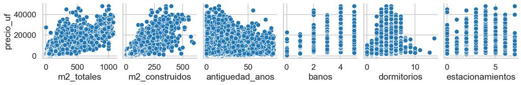

```python
sns.pairplot(data=df_filtrado, y_vars="precio_uf", x_vars=["m2_totales","m2_construidos","antiguedad_anos","banos","dormitorios","estacionamientos"])
plt.savefig(
    "../Figures/pairplot_variables_vs_precio.png",
    dpi=300,
    bbox_inches="tight"
)
```

```python
print("Como se ve la variable que mas afecta al precio es los metros cuadrados construidos")
print(df_filtrado["precio_uf"].corr(df_filtrado["m2_totales"]),"coeficiente correlacion metros cuadrados totales")
print(df_filtrado["precio_uf"].corr(df_filtrado["m2_construidos"]),"coeficiente correlacion metros cuadrados construidos")
print(df_filtrado["precio_uf"].corr(df_filtrado["antiguedad_anos"]),"coeficiente correlacion antiguedad")
print(df_filtrado["precio_uf"].corr(df_filtrado["banos"]),"coeficiente correlacion baños")
print(df_filtrado["precio_uf"].corr(df_filtrado["dormitorios"]),"coeficiente correlacion dormitorios")
```

```
Como se ve la variable que mas afecta al precio es los metros cuadrados construidos
0.7781426937734134 coeficiente correlacion metros cuadrados totales
0.8265782498754822 coeficiente correlacion metros cuadrados construidos
0.16288725351032077 coeficiente correlacion antiguedad
0.7299791351732495 coeficiente correlacion baños
0.5484750722427864 coeficiente correlacion dormitorios
```

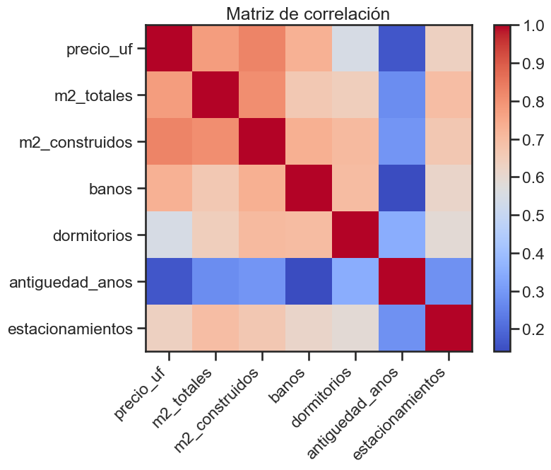

```python
import numpy as np

corr = df_filtrado.select_dtypes(include=["float64", "int64"]).corr()
fig, ax = plt.subplots(figsize=(8,6))
im = ax.imshow(corr, cmap="coolwarm", interpolation="nearest")
ax.set_xticks(range(len(corr.columns)))
ax.set_yticks(range(len(corr.columns)))
ax.set_xticklabels(corr.columns, rotation=45, ha="right")
ax.set_yticklabels(corr.columns)
plt.title("Matriz de correlación")
plt.colorbar(im)
plt.savefig(
    "../Figures/matriz_correlacion.png",
    dpi=300,
    bbox_inches="tight"
)
plt.show()
```

```
Estadísticas de dispersión del precio (UF):
Precio promedio: 8,329.28 UF
Desviación estándar: 7,416.85 UF
Rango (mín–máx): 382.00 – 48,000.00 UF
Coeficiente de variación: 89.05%
```

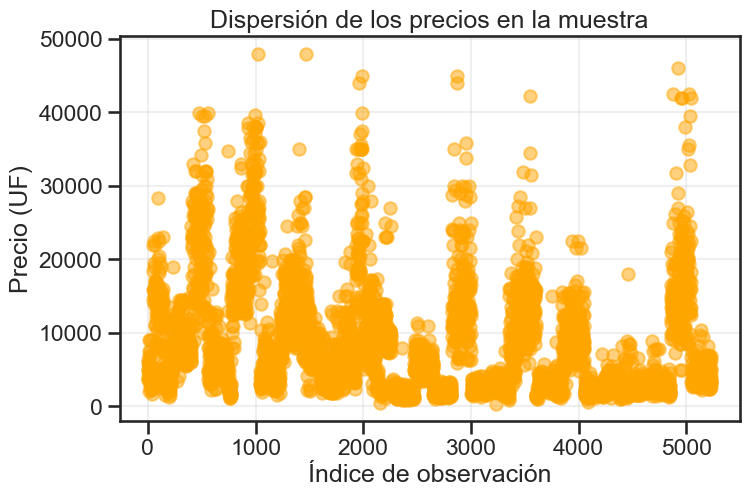

```python
import matplotlib.pyplot as plt

# Estadísticas
precio_mean = df_filtrado["precio_uf"].mean()
precio_std = df_filtrado["precio_uf"].std()
precio_min = df_filtrado["precio_uf"].min()
precio_max = df_filtrado["precio_uf"].max()
coef_variacion = (precio_std / precio_mean) * 100

print("Estadísticas de dispersión del precio (UF):")
print(f"Precio promedio: {precio_mean:,.2f} UF")
print(f"Desviación estándar: {precio_std:,.2f} UF")
print(f"Rango (mín–máx): {precio_min:,.2f} – {precio_max:,.2f} UF")
print(f"Coeficiente de variación: {coef_variacion:.2f}%")

# Gráfico
plt.figure(figsize=(8,5))
plt.scatter(range(len(df_filtrado)), df_filtrado["precio_uf"], alpha=0.5, color="orange")
plt.title("Dispersión de los precios en la muestra")
plt.xlabel("Índice de observación")
plt.ylabel("Precio (UF)")
plt.grid(alpha=0.3)
plt.savefig(
    "../Figures/dispersion_precios_muestra.png",
    dpi=300,
    bbox_inches="tight"
)
plt.show()
```

```python
# Medidas de forma y tendencia central
df_filtrado["precio_uf"].describe(percentiles=[.25, .5, .75, .9, .95])
```

```
count     5234.000000
mean      8329.284104
std       7416.854230
min        382.000000
25%       2849.250000
50%       5490.000000
75%      11990.000000
90%      18300.000000
95%      23500.000000
max      48000.000000
Name: precio_uf, dtype: float64
```

```
Comunas por precio promedio (UF):

comuna
Lo Barnechea    18973.832237
Vitacura        18922.255725
Las Condes      18561.645833
La Reina        15376.042254
Peñalolen       13697.012500
Colina          12848.668478
Providencia     12262.408397
Peñalolén        7976.113636
Huechuraba       7248.908587
Pudahuel         6921.678571
Name: precio_uf, dtype: float64
```

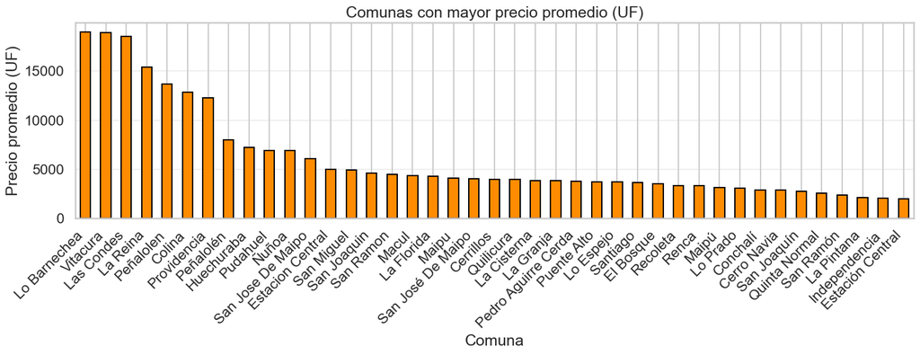

```
Comunas con menor precio promedio (UF):

comuna
Maipú               3132.475410
Lo Prado            3066.764706
Conchalí            2897.666667
Cerro Navia         2866.566667
San Joaquín         2718.720339
Quinta Normal       2550.390411
San Ramón           2353.800000
La Pintana          2116.080000
Independencia       2021.163743
Estación Central    1945.619632
Name: precio_uf, dtype: float64
```

```python
import matplotlib.pyplot as plt

precio_comuna = df_filtrado.groupby("comuna")["precio_uf"].mean().sort_values(ascending=False)

top10 = precio_comuna.head(10)
print("Comunas por precio promedio (UF):\n")
print(top10)

# Visualización
plt.figure(figsize=(15,6))
precio_comuna.plot(kind="bar", color="darkorange", edgecolor="black")
plt.title("Comunas con mayor precio promedio (UF)")
plt.ylabel("Precio promedio (UF)")
plt.xlabel("Comuna")
plt.xticks(rotation=45, ha='right')
plt.grid(axis="y", alpha=0.3)
plt.tight_layout()
plt.savefig(
    "../Figures/comunas_precio_promedio.png",
    dpi=300,
    bbox_inches="tight"
)
plt.show()



bottom10 = precio_comuna.tail(10)
print("\nComunas con menor precio promedio (UF):\n")
print(bottom10)
```

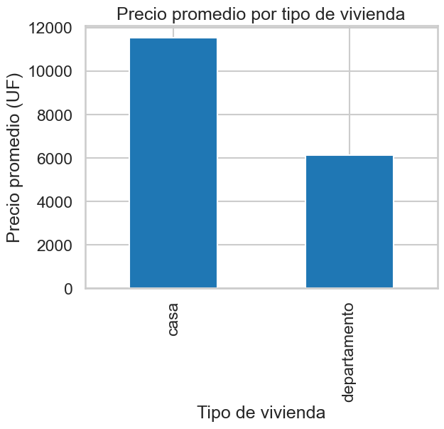

```python
df_filtrado.groupby("tipo_vivienda")["precio_uf"].mean().sort_values(ascending=False).plot(kind="bar")
plt.title("Precio promedio por tipo de vivienda")
plt.xlabel("Tipo de vivienda")
plt.ylabel("Precio promedio (UF)")
plt.savefig(
    "../Figures/precio_promedio_por_tipo_vivienda.png",
    dpi=300,
    bbox_inches="tight"
)
plt.show()
```

```python
amenidades = ["jardin", "piscina", "quincho", "condominio_cerrado"]

for a in amenidades:
    promedio = df_filtrado.groupby(a)["precio_uf"].mean()
    print(f"\nPrecio promedio según {a}:")
    print(promedio)
```

```
Precio promedio según jardin:
jardin
False    5338.718045
True     8489.407005
Name: precio_uf, dtype: float64

Precio promedio según piscina:
piscina
False    5989.935976
True     8485.685691
Name: precio_uf, dtype: float64

Precio promedio según quincho:
quincho
False    7153.218112
True     8951.503067
Name: precio_uf, dtype: float64

Precio promedio según condominio_cerrado:
condominio_cerrado
False    5441.351767
True     8739.505346
Name: precio_uf, dtype: float64
```

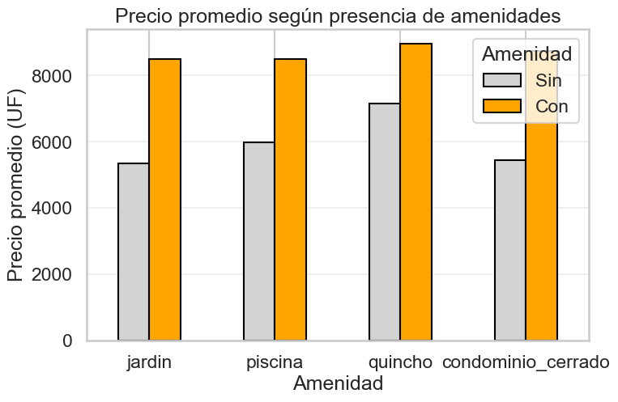

```python
import matplotlib.pyplot as plt

amenidades = ["jardin", "piscina", "quincho", "condominio_cerrado"]

# precios promedio para cada amenidad Si - No
promedios = {}
for a in amenidades:
    promedios[a] = df_filtrado.groupby(a)["precio_uf"].mean()


import pandas as pd
df_amenidades = pd.DataFrame(promedios)


df_amenidades = df_amenidades.T
df_amenidades.columns = ["Sin", "Con"]


df_amenidades.plot(kind="bar", figsize=(8,5), color=["lightgray", "orange"], edgecolor="black")
plt.title("Precio promedio según presencia de amenidades")
plt.ylabel("Precio promedio (UF)")
plt.xlabel("Amenidad")
plt.xticks(rotation=0)
plt.grid(axis="y", alpha=0.3)
plt.legend(title="Amenidad")
plt.savefig(
    "../Figures/precio_promedio_segun_amenidades.png",
    dpi=300,
    bbox_inches="tight"
)
plt.show()
```

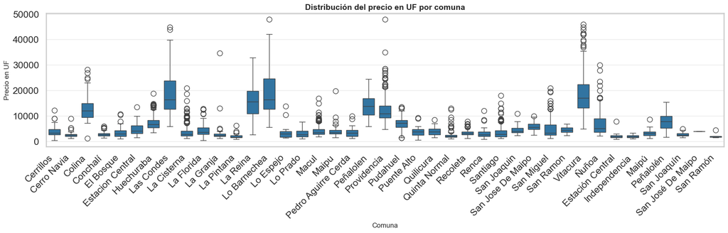

```python
import matplotlib.pyplot as plt
import seaborn as sns

plt.figure(figsize=(18,6))
sns.set_style("whitegrid")
ax = sns.boxplot(
    data=df_filtrado,
    x='comuna',
    y='precio_uf',
    width=0.7
)

plt.title("Distribución del precio en UF por comuna", fontsize=14, weight='bold')
plt.xlabel("Comuna", fontsize=12)
plt.ylabel("Precio en UF", fontsize=12)
plt.xticks(rotation=45, ha="right")
plt.grid(axis='y', alpha=0.3)
plt.tight_layout()
plt.savefig(
    "../Figures/boxplot_precio_uf_por_comuna.png",
    dpi=300,
    bbox_inches="tight"
)
plt.show()
```

```
Umbral percentil 99.5% precio/m²: 184.13 UF/m²
Filas antes: 5234 | después: 5207
```

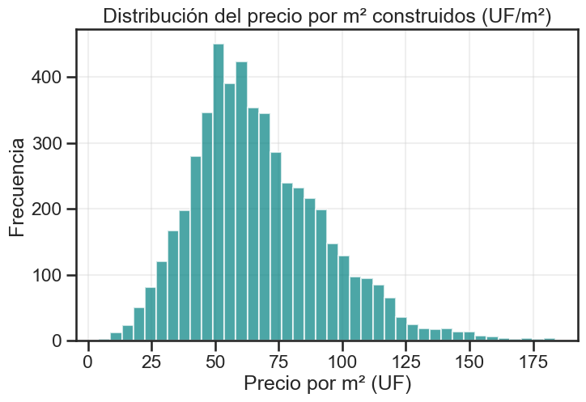

```python
df_filtrado["precio_m2"] = df_filtrado["precio_uf"] / df_filtrado["m2_construidos"]

umbral_precio_m2 = df_filtrado["precio_m2"].quantile(0.995)
df_m2_filtrado = df_filtrado[df_filtrado["precio_m2"] <= umbral_precio_m2]

print(f"Umbral percentil 99.5% precio/m²: {umbral_precio_m2:.2f} UF/m²")
print(f"Filas antes: {len(df_filtrado)} | después: {len(df_m2_filtrado)}")


plt.figure(figsize=(8,5))
plt.hist(df_m2_filtrado["precio_m2"], bins=40, color="teal", alpha=0.7)
plt.title("Distribución del precio por m² construidos (UF/m²)")
plt.xlabel("Precio por m² (UF)")
plt.ylabel("Frecuencia")
plt.grid(alpha=0.3)
plt.savefig(
    "../Figures/distribucion_precio_por_m2_construido.png",
    dpi=300,
    bbox_inches="tight"
)
plt.show()
```

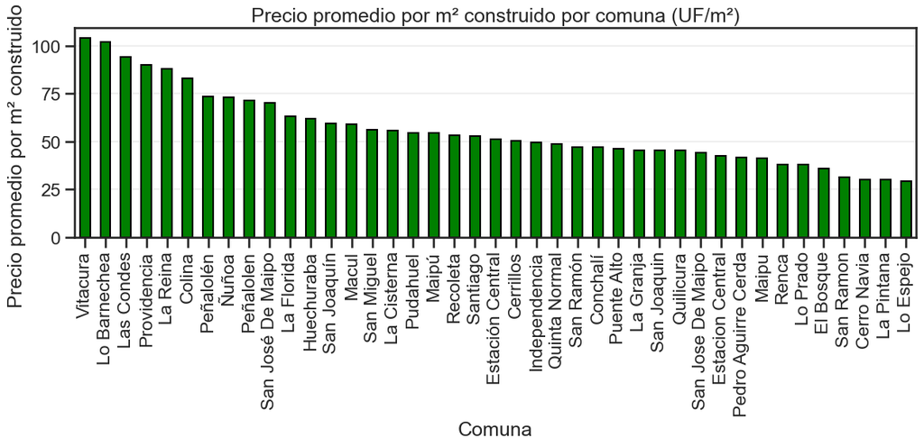

```
📊 Precio promedio por m² por comuna:
comuna
Vitacura               104.04
Lo Barnechea           102.07
Las Condes              94.20
Providencia             89.78
La Reina                88.03
Colina                  82.88
Peñalolén               73.25
Ñuñoa                   72.89
Peñalolen               71.40
San José De Maipo       70.18
La Florida              63.30
Huechuraba              61.78
San Joaquín             59.50
Macul                   59.05
San Miguel              56.24
La Cisterna             55.48
Pudahuel                54.34
Maipú                   54.26
Recoleta                53.27
Santiago                52.71
Estación Central        51.32
Cerrillos               50.43
Independencia           49.59
Quinta Normal           48.44
San Ramón               47.19
Conchalí                47.02
Puente Alto             45.95
La Granja               45.53
San Joaquin             45.33
Quilicura               45.24
San Jose De Maipo       44.08
Estacion Central        42.54
Pedro Aguirre Cerda     41.73
Maipu                   41.08
Renca                   37.86
Lo Prado                37.77
El Bosque               35.89
San Ramon               31.28
Cerro Navia             29.96
La Pintana              29.89
Lo Espejo               29.15
Name: precio_m2, dtype: float64
```

```python
import matplotlib.pyplot as plt

# precio promedio por m² para todas las comunas
precio_m2_comuna = df_m2_filtrado.groupby("comuna")["precio_m2"].mean().sort_values(ascending=False)


plt.figure(figsize=(12,6))
precio_m2_comuna.plot(kind="bar", color="green", edgecolor="black")
plt.title("Precio promedio por m² construido por comuna (UF/m²)")
plt.ylabel("Precio promedio por m² construido (UF)")
plt.xlabel("Comuna")
plt.xticks(rotation=90)
plt.grid(axis="y", alpha=0.3)
plt.tight_layout()
plt.savefig(
    "../Figures/precio_m2_promedio_por_comuna.png",
    dpi=300,
    bbox_inches="tight"
)
plt.show()

print("📊 Precio promedio por m² por comuna:")
print(precio_m2_comuna.round(2))
```

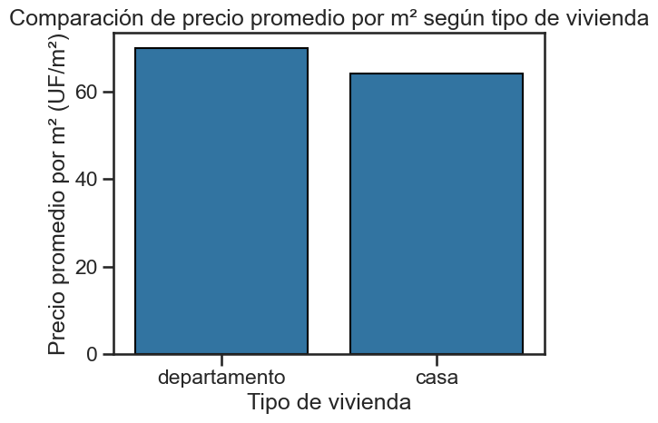

```
Precio promedio por m² por tipo de vivienda:
tipo_vivienda
departamento    69.82
casa            63.99
Name: precio_m2, dtype: float64
```

```python
# Comparación general del precio por m² entre tipos de vivienda
precio_m2_tipo = df_m2_filtrado.groupby("tipo_vivienda")["precio_m2"].mean().sort_values(ascending=False)

plt.figure(figsize=(6,5))
sns.barplot(
    x=precio_m2_tipo.index,
    y=precio_m2_tipo.values,
    edgecolor="black"
)
plt.title("Comparación de precio promedio por m² según tipo de vivienda")
plt.xlabel("Tipo de vivienda")
plt.ylabel("Precio promedio por m² (UF/m²)")
plt.tight_layout()
plt.savefig("../Figures/precio_m2_tipo_vivienda", dpi=300, bbox_inches="tight")
plt.show()

print("Precio promedio por m² por tipo de vivienda:")
print(precio_m2_tipo.round(2))
```

# Análisis Exploratorio de Datos (EDA) del Mercado Inmobiliario – Región Metropolitana

## 1️. Propósito general

El objetivo del EDA fue **explorar y comprender el comportamiento de los precios de viviendas** en la Región Metropolitana, utilizando como fuente el dataset `Dataset_viviendas_final.csv` tras un proceso de limpieza y filtrado basado en percentiles.  
El análisis busca identificar **patrones de variación en el precio (en UF)** según factores estructurales (m², baños, dormitorios), temporales (antigüedad), geográficos (comuna) y de equipamiento (amenities como piscina, quincho, condominio, jardín, etc.).

## 2️. Preparación y limpieza del dataset

Se aplicaron filtros utilizando cuantiles para remover **outliers extremos** que distorsionaban la escala de los gráficos.  
Los límites usados fueron:

- `precio_uf` ≤ percentil 98
- `m2_totales` ≤ percentil 93
- `m2_construidos`, `antiguedad_anos`, `baños`, `estacionamientos` ≤ percentil 98

Además:

- Se normalizaron nombres de comunas (`str.title()`, eliminación de espacios, caracteres no imprimibles).
- Se eliminaron registros con valores nulos en variables clave (`comuna`, `tipo_vivienda`, `educacion`, `salud`, `comercios`, `amenities`, etc.).

## 3️. Visualizaciones y hallazgos principales

### 🔹 3.1 Relación entre precio y superficie construida

Los primeros gráficos de dispersión (`precio_uf` vs `m2_construidos` y `precio_uf` vs `m2_totales`) muestran una **relación positiva**:  
las viviendas más grandes tienden a tener un mayor precio absoluto.  
No obstante, la dispersión vertical indica que existen **otros factores** (ubicación, tipo, equipamiento) que también influyen en el valor.

El filtrado por percentiles mejoró significativamente la visualización, evitando que los outliers arrastraran la escala.

### 🔹 3.3 Dispersión general del precio

El gráfico de dispersión del precio en función del índice de observación confirma una **alta variabilidad**, con clústeres de precios intermedios y algunos peaks que representan viviendas de lujo.  
La mayoría de las propiedades se concentra bajo las 10.000 UF, lo que concuerda con el rango medio del mercado.

### 🔹 3.4 Matriz de correlación

En conjunto, los resultados confirman que el **tamaño y las características estructurales** son los principales determinantes del precio.

### 🔹 3.5 Precio promedio por comuna

La diferencia entre los extremos supera las 15.000 UF, evidenciando la **desigualdad en cuanto a comunas del mercado inmobiliario**.

### 🔹 3.6 Precio promedio por tipo de vivienda

Esto se debe a que los departamentos suelen ubicarse en zonas de mayor densidad y acceso, mientras que las casas tienden a encontrarse en sectores periféricos o con más terreno.

### 🔹 3.7 Precio promedio por m² construido por comuna

El **precio por m²** resulta una métrica más justa para comparar comunas, mostrando el contraste de la Región Metropolitana.

### 🔹 3.8 Relación entre precio y amenidades.

Se comparó el **precio promedio** según la presencia o ausencia de amenidades (True/False):

[output not shown]

No obstante, es importante destacar que este efecto **no se debe exclusivamente a la presencia de una amenidad específica**.  
En la mayoría de los casos, las propiedades con piscina, quincho o jardín se ubican en **zonas residenciales de mayor valor o comunas más exclusivas**, lo que eleva de forma natural su precio.  
Por tanto, el impacto observado responde a una **combinación de factores** —ubicación, superficie, tipo de vivienda y nivel de equipamiento— más que al efecto de tener estas caraterísticas.

### 🔹 3.9 Boxplot de precios por comuna

El boxplot comparativo por comuna muestra:

- Comunas de alto valor (Vitacura, Lo Barnechea, Las Condes) con **amplia dispersión** y presencia de outliers altos.
- Comunas periféricas con precios **más homogéneos y concentrados**.

Esto sugiere que las comunas más exclusivas presentan **mayor diversidad de oferta** (desde departamentos medianos hasta mansiones de lujo).

### 🔹 3.10 Distribución del precio por m² construido

El histograma del precio por m² muestra una distribución **asimétrica a la derecha**, concentrada entre **40 y 70 UF/m²**, rango típico del mercado.  
Los valores más altos corresponden a sectores más caros.  
La forma sesgada confirma que el mercado tiene **una gran concentración en precios medios** y **una cola larga hacia viviendas de lujo**.

## Conclusión general

El análisis exploratorio demuestra que el **mercado inmobiliario de la Región Metropolitana es altamente segmentado y dependiente de la localización geográfica**.  
La combinación de factores físicos, socioeconómicos y urbanos determina la gran variabilidad de precios observada.

El uso de **percentiles** para limpiar los datos y la integración de múltiples visualizaciones permitió construir una **visión integral del mercado**, identificando patrones claros:

- el **precio por m²** como mejor indicador de valor real,
- la **importancia de la ubicación**

Estos hallazgos sientan una base sólida para futuros modelos predictivos o estudios de valoración inmobiliaria basados en aprendizaje automático.